# My First MArkdown file

Here, we want to load some data:

```r
getwd()
```

```
## [1] "/Users/tristanreitz/Desktop/R Programming"
```

```r
setwd("/Users/tristanreitz/Desktop/R Programming")
library(dplyr)
```

```r
library(ggplot2)
```

Open CSV with data on it and check its summary:

```r
activity <- read.csv("activity.csv")
overview <- summary(activity)

overview
```

```
##      steps                date          interval
##  Min.   :  0.00   2012-10-01:  288   Min.   :   0.0
##  1st Qu.:  0.00   2012-10-02:  288   1st Qu.: 588.8
##  Median :  0.00   2012-10-03:  288   Median :1177.5
##  Mean   : 37.38   2012-10-04:  288   Mean   :1177.5
##  3rd Qu.: 12.00   2012-10-05:  288   3rd Qu.:1766.2
##  Max.   :806.00   2012-10-06:  288   Max.   :2355.0
##  NA's   :2304     (Other)   :15840
```

Instructions: What is mean total number of steps taken per day?

For this part of the assignment, you can ignore the missing values in the dataset.

Calculate the total number of steps taken per day

```r
activityna <- na.omit(activity)
```

```r
actday <- group_by(activityna, date)
actday <- summarize(actday, steps=sum(steps))

summary(actday)
```

```
##          date        steps
##  2012-10-02: 1   Min.   :   41
##  2012-10-03: 1   1st Qu.: 8841
##  2012-10-04: 1   Median :10765
##  2012-10-05: 1   Mean   :10766
##  2012-10-06: 1   3rd Qu.:13294
##  2012-10-07: 1   Max.   :21194
##  (Other)   :47
```

Plotting the data

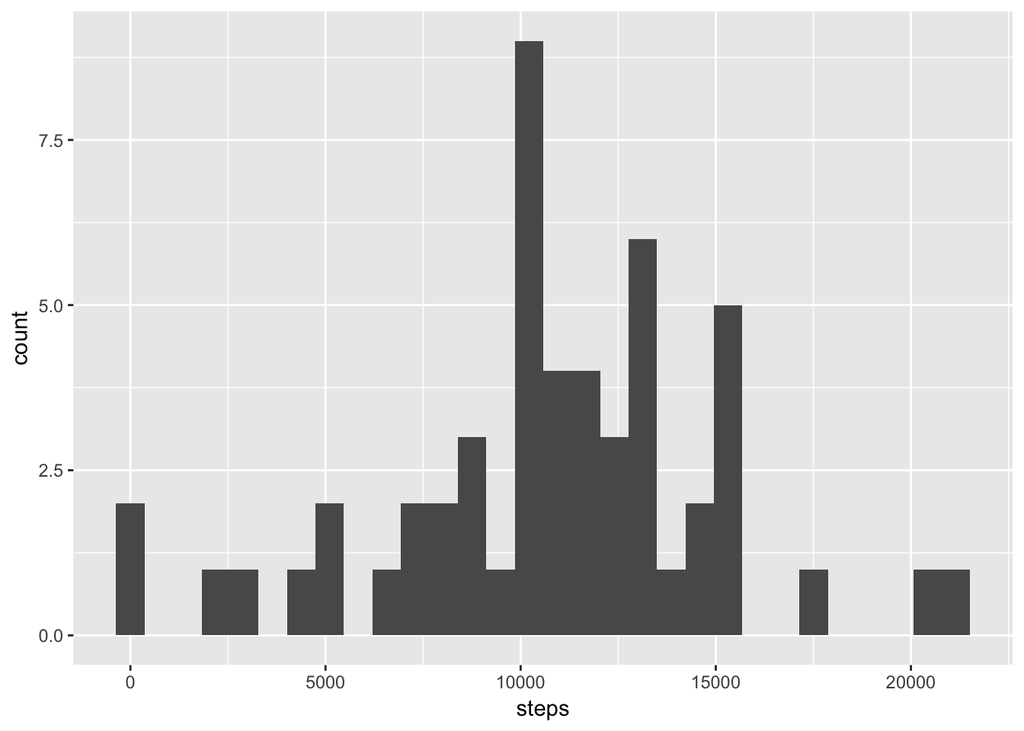

```r
qplot(steps, data=actday)
```

Finding the mean

```r
mean(actday$steps)
```

```
## [1] 10766.19
```

Finding the median

```r
median(actday$steps)
```

```
## [1] 10765
```

What is the average daily activity pattern?

Make a time series plot (i.e. 𝚝𝚢𝚙𝚎 = “𝚕”) of the 5-minute interval (x-axis) and the average number of steps taken, averaged across all days (y-axis)

Which 5-minute interval, on average across all the days in the dataset, contains the maximum number of steps?

Now we put into 5 minute intervals:

```r
actioninterval <- group_by(activityna, interval)
actioninterval <- summarize(actioninterval, steps=mean(steps))
```

Now we plot them

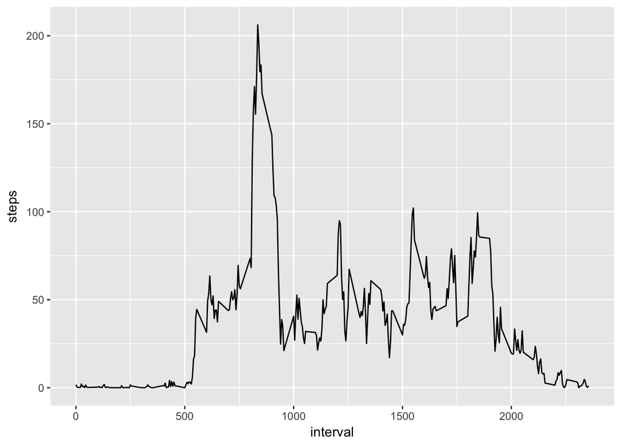

```r
ggplot(actioninterval, aes(interval, steps)) + geom_line()
```

Which 5-minute interval, on average across all the days in the dataset, contains the maximum number of steps?

```r
actioninterval[actioninterval$steps==max(actioninterval$steps),]
```

```
## # A tibble: 1 x 2
##   interval    steps
##      <int>    <dbl>
## 1      835 206.1698
```

Imputing missing values

Note that there are a number of days/intervals where there are missing values (coded as 𝙽𝙰). The presence of missing days may introduce bias into some calculations or summaries of the data.